# Chapter11 matplotlibの使い方

### 11-1

**plt.plot()** を用いて、以下の2つの関数をプロットするプログラムを完成させなさい  
（参考：11.1.1 グラフにデータをプロットする～11.2.2 系列ラベルを設定する）

①　$y_1 = sin(x)$  
②　$y_2 = sin(x + \frac{\pi}{2})$  
※xの範囲は（$ -\pi \leqq x \leqq \pi$）とする

なお、描くグラフは以下の設定とすること

- x軸のデータは **np.linspace()** を利用し、 $-\pi$ から $\pi$ の範囲で50個のデータを用意する
- x軸の目盛りは、$[-\pi, -\frac{1}{2}\pi, 0, \frac{1}{2}\pi, \pi]$ の位置にそれぞれ [ -180°、-90°、0°、90°、180°] と表示する
- グラフのタイトルを「 **graphs of trigonometric functions** 」と表示する
- x軸は"X"、y軸は"Y"と表示する
- ①のグラフは **y=sin(x)** とラベルを付けて、赤でプロットする
- ②のグラフは **y=sin(x+pi/2)** とラベルを付けて、緑でプロットする
- グリッドを表示する
- 凡例を表示する

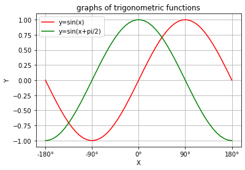

```python
import matplotlib.pyplot as plt
import numpy as np
%matplotlib inline

# X軸のデータはnp.linspace()を利用し-pi～piの範囲で50個用意する
# piはnp.piを利用する
x = np.linspace(-np.pi, np.pi, 50)

# y1のデータを用意する
y1 = np.sin(x)

# y2のデータを用意する
y2 = np.sin(x+np.pi/2)

# X軸用の目盛りの位置をリストで用意する
positions = [-np.pi,-1/2*np.pi,0, 1/2*np.pi, np.pi]

# X軸用の目盛りの表示文字列をリストで用意する
labels =["-180°","-90°","0°","90°","180°"]

# グラフのx軸に目盛りを設定する
plt.xticks(positions, labels)

# グラフのタイトルを設定する
plt.title("graphs of trigonometric functions")

# グラフのx軸とy軸に名前を設定する
plt.xlabel("X")
plt.ylabel("Y")

# グラフにグリッドを表示する
plt.grid(True)

# データx, y1をグラフにプロットし、"y=sin(x)"とラベルを付けて赤で表示する
plt.plot(x, y1, color="r", label="y=sin(x)")

# データx, y2をグラフにプロットし、"y=sin(x+pi/2)"とラベルを付けて緑で表示する
plt.plot(x, y2, color="g", label="y=sin(x+pi/2)")

# 凡例を設定する
plt.legend(["y=sin(x)", "y=sin(x+pi/2)"])

plt.show()
```

### 11-2

1×2のグラフレイアウトを作成し、左側に y = sin(x)、右側に y = cos(x)のグラフをプロットするプログラムを完成させなさい。  
なお、描くグラフは以下の設定とすること。  
（参考：11.3.1 図の大きさを設定する～11.3.7 サブプロット内のグラフの軸に目盛りを設定する）

- 図が表示される領域の大きさは横9インチ×縦4インチになるように設定する
- x軸のデータはnp.linspace()を利用し、 $-\pi$ から $\pi$ の範囲で50個のデータを用意する
- x軸の目盛りは、$[-\pi, -\frac{1}{2}\pi, 0, \frac{1}{2}\pi, \pi]$ の位置にそれぞれ [ -180°、-90°、0°、90°、180°] と表示する
- グラフのタイトルはそれぞれ「y=sin(x)」、「y=cos(x)」と表示する
- x軸は"X"、y軸は"Y"と表示する
- グリッドを表示する
- 2つのグラフが重ならないように、サブプロット間を縦横ともに0.4の割合で空ける

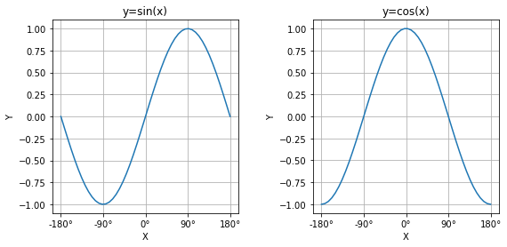

```python
import matplotlib.pyplot as plt
import numpy as np
%matplotlib inline

# X軸のデータはnp.linspace()を利用し-pi～piの範囲で50個用意する
x = np.linspace(-np.pi, np.pi, 50)

# X軸用の目盛りの位置をリストで用意する
positions = [-np.pi,-1/2*np.pi,0, 1/2*np.pi, np.pi]

# X軸用の目盛りの表示文字列をリストで用意する
labels = ["-180°","-90°","0°","90°","180°"]

# 図が表示される領域の大きさは横9インチ×縦4インチになるように設定する
fig = plt.figure(figsize=(9, 4))

# y=sin(x)のグラフ用のサブプロットを生成する
ax = fig.add_subplot(1,2,1)

# サブプロットaxのグラフにグリッドを表示する
ax.grid(True)

# サブプロットaxのグラフのタイトルを設定する
ax.set_title("y=sin(x)")

# サブプロットaxのグラフのx軸、y軸に名前を設定する
ax.set_xlabel("X")
ax.set_ylabel("Y")

# サブプロットaxのグラフのx軸に目盛りを設定する
ax.set_xticks(positions)
ax.set_xticklabels(labels)

# Y軸データを生成する
y = np.sin(x)

# データx,yをグラフにプロットし、表示する
ax.plot(x, y)

# y=cos(x)のグラフ用のサブプロットを生成する
ax = fig.add_subplot(1,2,2)

# サブプロットaxのグラフにグリッドを表示する
ax.grid(True)

# サブプロットaxのグラフのタイトルを設定する
ax.set_title("y=cos(x)")

# サブプロットaxのグラフのx軸、y軸に名前を設定する
ax.set_xlabel("X")
ax.set_ylabel("Y")

# サブプロットaxのグラフのx軸にラベルを設定する
ax.set_xticks(positions)
ax.set_xticklabels(labels)

# Y軸データを生成する
y = np.cos(x)

# データx,yをグラフにプロットし、表示する
ax.plot(x, y)

# サブプロット同士が重ならないように設定する
plt.subplots_adjust(wspace=0.4, hspace=0.4)

plt.show()
```